# 5.3: Intersections and distance calculations

### Unit 5: Spatial

#### Lesson 3: AIS ship tracks

#### New functions: st_crop(), st_make_valid(), st_intersection(), st_drop_geometry()

Automatic Identification System (AIS) is an automatic tracking system that uses tranceivers on vessels to detect their location in space and time. AIS is used secondarily to radar to avoid vessel collisions. Large vessels and passenger ships are required to use AIS. The US Bureau of Ocean Energy Management (BOEM) and NOAA provide AIS data collected by the US Coast Guard for free at https://hub.marinecadastre.gov/pages/vesseltraffic

AIS data is huuuuggee!! There are a lot of ships in the water and each ping from an AIS unit is a new row of data. I downloaded AIS data for just one day: January 25, 2017. This is over 200 MB spreadsheet with almost 8 million rows. This is a bit big to include in a GitHub repo. In the script `ais_reduce.R` I read in the data, cropped it to a bounding box around FL, GA, and SC, removed duplicate rows and rows with no vessel `call_sign`, grabbed only vessels with the status == 0 “under way using engine”. Then I wrote this much smaller file (~30 MB) out to a `.csv` file that has a more manageable size, but is otherwise equivalent to what you could download directly from the website.

We can use the AIS data to get a look at the amount of vessel traffic that occurs in the Southeast US North Atlantic right whale critical breeding habitat. Much of this critical habitat has been designated a Seasonal Management Area, where vessels > 65 feet long (20 meters) are required to slow down to < 10 knots during the calving season (from November 15 - April 15 each year). Vessels < 65 feet in length are also encouraged, but not required, to slow down to < 10 knots. NOAA Fisheries issued this ruling to reduce the risk of right whale ship strikes. The AIS data includes ship length (in meters) as well as Heading (direction your ship is pointed at), cog (Course Over Ground - direction your ship is actually heading) and sog (Speed Over Ground in knots). AIS data from the US Coast Guard uses the NAD83 CRS (EPSG:4269). For more information on AIS variables, see: https://www.navcen.uscg.gov/ais-class-a-reports and http://coast.noaa.gov/data/marinecadastre/ais/data-dictionary.pdf

Let’s start by loading in the subsetted AIS data, the shapefiles for the right whale critical habitat (that we used earlier) and the world coastline data in R’s `mapdata` package. We will crop the coastline data to the same bounding box that I used when I reduced the size of the original (larger) AIS data.

```r
library(tidyverse)
library(sf)
## Warning: package 'sf' was built under R version 4.5.3
library(mapdata)
## Warning: package 'mapdata' was built under R version 4.5.3
## Warning: package 'maps' was built under R version 4.5.3
library(lubridate)
```

```r
## AIS data; Downloaded for January 25, 2017
# https://hub.marinecadastre.gov/pages/vesseltraffic
# (not included in data folder bc ~220MB)
# subsetted with script ais_reduce.R in this repo
ais_day = read.csv('data/processed_ais/ais_2017-01-25.csv')
head(ais_day)
##        mmsi      base_date_time longitude latitude sog   cog heading
## 1 367368480 2017-01-25 00:00:00 -81.06459 32.08201 0.1 193.1     263
## 2 319009300 2017-01-25 00:00:01 -80.14378 25.80798 0.0 339.4     296
## 3 305755000 2017-01-25 00:00:00 -77.37085 33.51950 5.0 226.4     230
## 4 538071136 2017-01-25 00:00:00 -80.10632 26.11553 0.0 184.0      97
## 5 367667560 2017-01-25 00:00:08 -80.22379 32.69062 0.0 229.4     351
## 6 367487960 2017-01-25 00:00:02 -80.33789 32.47256 0.0  74.1      NA
##    vessel_name        imo call_sign vessel_type status length width draft cargo
## 1      FLORIDA              WDE5561          NA      0     30     8    NA    52
## 2    ROCK STAR IMO9557692     ZCYK3        1019      0     49     9   2.3    NA
## 3   BBC PARANA IMO9571387     V2FQ3        1004      0    143    23   9.7    NA
## 4 NEVER ENOUGH IMO9386366     V7RM2        1019      0     48     9   2.4    37
## 5 SEA CRESCENT IMO8984563   WDH9391          NA      0     27     9    NA    NA
## 6  MONICA LYNN              WDF7771          NA      0     20     8    NA    52
##   transceiver
## 1          NA
## 2          NA
## 3          NA
## 4          NA
## 5          NA
## 6          NA

# Coastline data
lat_bounds = c(25, 34)
lon_bounds = c( -82, -76)
world_map = map_data("worldHires", ylim = lat_bounds, xlim = lon_bounds)
dim(world_map)
## [1] 62929     6

#Read in US critical habitat shapefiles
# https://www.greateratlantic.fisheries.noaa.gov/educational_resources/gis/data/index.html
USA_crit_hab = st_read('data/North_Atlantic_Right_Whale_Critical_Habitat/','North_Atlantic_Right_Whale_Critical_Habitat') # reads in set of shapefiles
## Reading layer `North_Atlantic_Right_Whale_Critical_Habitat' from data source
##   `C:\Users\avery\OneDrive\Desktop\MSCI 709\Unit 5\unit_5_spatial\data\North_Atlantic_Right_Whale_Critical_Habitat'
##   using driver `ESRI Shapefile'
## Simple feature collection with 2 features and 23 fields
## Geometry type: POLYGON
## Dimension:     XY
## Bounding box:  xmin: -81.46045 ymin: 28 xmax: -66.88542 ymax: 44.82886
## Geodetic CRS:  NAD83
```

Now let’s plot everything that we loaded up. Note that the AIS data is still quite large, with 271,292 rows. Each row represents a lat/lon coordinate where an AIS signal was emitted. Putting all of these points on a map takes some processing time, but you can significantly speed it up by never actually printing the plot out to the console. Do this by saving the plot to a variable name and using `ggsave()` to write that plot out to a file (like a .pdf, .png or .jpg). Then just open up that file to see your map.

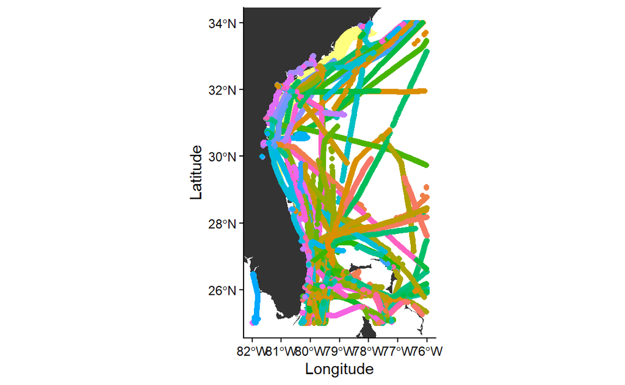

```r
# plot critical habitats and carcass locations
ais_map_pts = ggplot()+
  geom_polygon(data = world_map, aes(x = long, y = lat, group = group)) + # add coastline
  geom_sf(data=USA_crit_hab, alpha = 0.5, color=NA, fill='yellow') +
  geom_point(data = ais_day, aes(x = longitude, y = latitude, color = call_sign)) +
  coord_sf(xlim = lon_bounds, ylim = lat_bounds) + # Crop map edges
  guides(color="none") +
  ylab("Latitude") + xlab("Longitude") + theme_classic()

ais_map_pts
```

```r
ggsave(ais_map_pts, filename='figures/ais_pts_2017-01-25.pdf', device="pdf", height=5, width=4)
```

Now we’ll do some analysis. Let’s keep only the ship points that intersect with the right whale critical habitat. Then let’s figure out whether any of these ships are breaking the law. Are any ships with Length > 65ft (20m) traveling at SOG > 10 knots?

```r
# Find AIS pings that intersect with RW habitat
Sys.time()
## [1] "2026-04-05 23:37:34 EDT"
ships_RW_intersect = ais_day %>%
  st_as_sf(coords=c("longitude", "latitude"), crs=4269) %>% # AIS uses NAD83 CRS
  st_intersection(USA_crit_hab %>% dplyr::select(geometry))
## Warning: attribute variables are assumed to be spatially constant throughout
## all geometries
Sys.time()
## [1] "2026-04-05 23:37:53 EDT"

law_breakers = ships_RW_intersect %>%
  filter(length > 20, # meters
         sog > 10)

dim(law_breakers)
## [1] 1969   16
summary(law_breakers)
##       mmsi           base_date_time          sog             cog
##  Min.   :210063000   Length:1969        Min.   :10.10   Min.   :  0.3
##  1st Qu.:338923000   Class :character   1st Qu.:10.70   1st Qu.:118.1
##  Median :367721220   Mode  :character   Median :12.60   Median :220.6
##  Mean   :406728886                      Mean   :12.92   Mean   :204.7
##  3rd Qu.:538004086                      3rd Qu.:14.50   3rd Qu.:299.0
##  Max.   :636091990                      Max.   :20.80   Max.   :359.9
##
##     heading      vessel_name            imo             call_sign
##  Min.   :  0.0   Length:1969        Length:1969        Length:1969
##  1st Qu.:119.0   Class :character   Class :character   Class :character
##  Median :221.0   Mode  :character   Mode  :character   Mode  :character
##  Mean   :203.4
##  3rd Qu.:298.0
##  Max.   :359.0
##  NA's   :52
##   vessel_type         status      length          width           draft
##  Min.   :  70.0   Min.   :0   Min.   : 29.0   Min.   : 9.00   Min.   : 2.40
##  1st Qu.:1004.0   1st Qu.:0   1st Qu.:180.0   1st Qu.:28.00   1st Qu.: 9.70
##  Median :1004.0   Median :0   Median :243.0   Median :32.00   Median :12.30
##  Mean   : 991.4   Mean   :0   Mean   :233.6   Mean   :32.69   Mean   :11.53
##  3rd Qu.:1004.0   3rd Qu.:0   3rd Qu.:302.0   3rd Qu.:43.00   3rd Qu.:14.20
##  Max.   :1024.0   Max.   :0   Max.   :337.0   Max.   :46.00   Max.   :15.00
##  NA's   :44                                   NA's   :79      NA's   :119
##      cargo       transceiver             geometry
##  Min.   :32.00   Mode:logical   POINT        :1969
##  1st Qu.:70.00   NA's:1969      epsg:4269    :   0
##  Median :70.00                  +proj=long...:   0
##  Mean   :71.02
##  3rd Qu.:73.00
##  Max.   :80.00
##  NA's   :712

length(unique(law_breakers$call_sign)) # how many law breakers?
## [1] 48
unique(law_breakers$vessel_name) # what are their names?
##  [1] "FLORETGRACHT"         "MOL MAGNIFICENCE"     "YORKTOWN EXPRESS"
##  [4] "EMERALD PRINCESS II"  "CAPE CHARLES"         "HOEGH MANILA"
##  [7] "HEROIC ACE"           "WYE RIVER"            "BISHU HIGHWAY"
## [10] "BASIC RAINBOW"        "UNITED HARMONY"       "MONTE ACONCAGUA"
## [13] "EVER LOVELY"          "ZIM NINGBO"           "CPO BALTIMORE"
## [16] "OOCL KUALA LUMPUR"    "MAERSK VALLVIK"       "NORTHERN GUILD"
## [19] "GRANDE LUANDA"        "NYK ALTAIR"           "EVER LADEN"
## [22] "PACIFIC REEFER"       "ENDURANCE"            "SEALAND WASHINGTON"
## [25] "EVER LAWFUL"          "CMA CGM BIANCA"       "WESTERN MAPLE"
## [28] "STAR HANSA"           "AS FEDERICA"          "HALIFAX EXPRESS"
## [31] "MAERSK UTAH"          "CARNIVAL ECSTASY"     "MSC JOANNA"
## [34] "CORAL COAST"          "OCEAN GLORY"          "CG MARIA BRAY"
## [37] "C-TRACTOR 13"         "MAERSK KAWASAKI"      "BBC PARANA"
## [40] "OSG COURAGEOUS"       "MAERSK WINNIPEG"      "MSC VANESSA"
## [43] "SUMMIT AFRICA"        "CELIA"                "MSC ANIELLO"
## [46] "MAERSK MEMPHIS"       "MOL MANEUVER"         "CMA CGM CHATEAU D'IF"
```

Are you kidding me? We’ve got more than 1900 AIS pings from big ships breaking the speed limit on January 25, 2017 off the Southeast US - the peak of the right whale calving season.

Now we can convert our AIS points to ship track lines. We can use the `ymd_hms()` function in the `lubridate` package to convert the column `base_date_time` into a date/time variable (of type `POSIXct`) that R will actually recognize. Then we can simply use the `arrange()` function in dplyr to sort our data by date/time to make sure they are in chronological order. Once that is done, we can group the AIS points by each vessel’s unique `call_sign` and collapse the series of AIS points into ship track lines. Note that arranging the data chronologically and grouping by vessel are critical steps so that the ship tracks make sense.

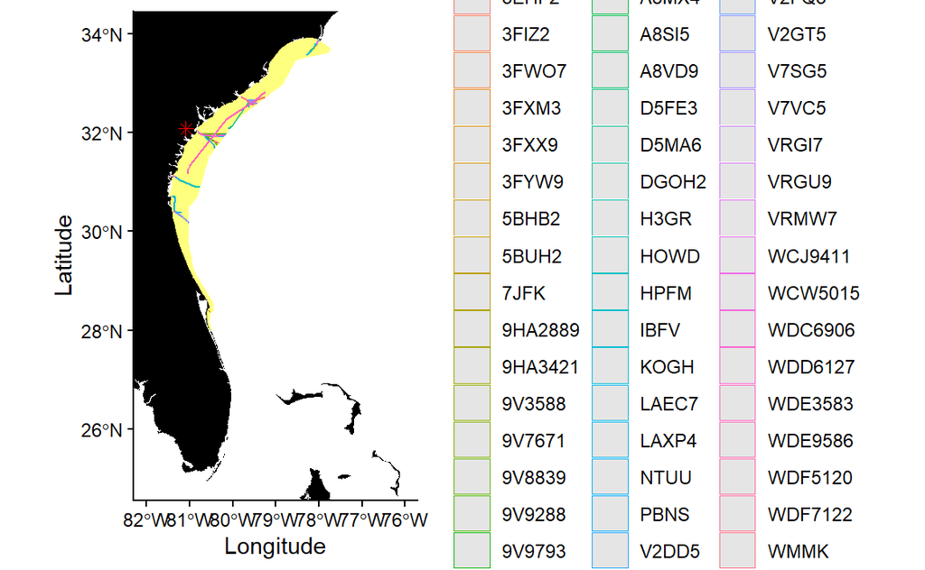

```r
illegal_paths = law_breakers %>%
  mutate(date_time = lubridate::ymd_hms(base_date_time)) %>% # date_time is POSIXct class (calendar/time)
  arrange(date_time) %>% # ensure ship tracks points are in chronological order
  group_by(call_sign) %>%
  summarise(do_union=FALSE) %>% # collapses data into multipoint; do_union=FALSE prevents reordering points
  st_cast("LINESTRING") %>%
  st_make_valid() # gets rid of lines with <2 points
head(illegal_paths)
## Simple feature collection with 6 features and 1 field
## Geometry type: LINESTRING
## Dimension:     XY
## Bounding box:  xmin: -80.84238 ymin: 31.96013 xmax: -79.24053 ymax: 32.72129
## Geodetic CRS:  NAD83
## # A tibble: 6 × 2
##   call_sign                                                             geometry
##   <chr>                                                         <LINESTRING [°]>
## 1 3EHF2     (-79.24053 32.714, -79.24552 32.71265, -79.25051 32.71131, -79.2555…
## 2 3FIZ2     (-80.15245 31.97637, -80.15716 31.97606, -80.16206 31.97573, -80.16…
## 3 3FWO7     (-80.72487 31.96883, -80.72853 31.96999, -80.73233 31.97131, -80.73…
## 4 3FXM3     (-80.73939 31.97433, -80.74289 31.97579, -80.74714 31.97761, -80.75…
## 5 3FXX9     (-80.70728 31.96665, -80.71106 31.96725, -80.71489 31.96785, -80.71…
## 6 3FYW9     (-80.68026 31.96013, -80.68453 31.96122, -80.689 31.96212, -80.6939…
# plot ship tracks
# illegal_paths_for_plot = illegal_paths[-16,]
# install.packages("mapview")
# library(mapview)
# npts(illegal_paths, by_feature=T)
#
# ggplot() +
#   geom_sf(data=illegal_paths_for_plot)
law_breaking_map = ggplot()+
  geom_polygon(data = world_map, aes(x = long, y = lat, group = group), fill = "black", color = NA) + # add coastline
  geom_sf(data=USA_crit_hab, alpha = 0.5, color=NA, fill='yellow') +
  geom_sf(data=illegal_paths, aes(color=call_sign)) + #  fill=CallSign # useful if printing legend
  coord_sf(xlim = lon_bounds, ylim = lat_bounds) + # Crop map edges
  geom_point(aes(x=-81.09, y=32.08), size=2, color="red", shape=8) + # Savannah
  #guides(color="none") +
  ylab("Latitude") + xlab("Longitude") +
  theme_classic()

law_breaking_map
```

Now that we have converted our AIS points into lines, we can calculate the length of the ships’ paths.

```r
# What are the lengths of the ship tracks that intersected the RW critical habitat?
illegal_path_lengths = illegal_paths %>%
  mutate(track_length_m = st_length(geometry)) # Calculate length of ship tracks in meters
class(illegal_path_lengths$track_length_m) # units class, double type; can convert to numeric with as.numeric()
## [1] "units"

tot_illegal_path = sum(illegal_path_lengths$track_length_m)
tot_illegal_path
## 1637180 [m]

# or convert the lengths from units class to numeric class and calculate total track length using dplyr:
tot_illegal_path = illegal_paths %>%
  mutate(track_length_m = as.numeric(st_length(geometry))) %>%
  summarize(tot_track_length_m = sum(track_length_m)) %>%
  mutate(tot_track_length_km = tot_track_length_m/1000) %>%
  st_drop_geometry()

tot_illegal_path
## # A tibble: 1 × 2
##   tot_track_length_m tot_track_length_km
## *              <dbl>               <dbl>
## 1           1637180.               1637.
```

Geeze. 1,637.18 km of ship tracks illegally zooming through the calving area. If I was presenting this research formally, I’d do a bit more analytical work to remove portions of a ship’s track when their speed drops below 10knots by breaking tracks into segments, but as a first pass, this gives us a reasonable picture of compliance to the critical habitat regulations.

You can easily imagine loading the full AIS data set for the breeding season (November - April) and asking these questions across the whole month. Does the ship traffic change between weekdays and weekends? Grab data from other years - does ship traffic change over time? Are higher vessel traffic years associated with more ship strikes, or calving success? What types of vessels enter the critical habitat? How many vessels are compliant to NOAA’s <10 knot rule? Which vessels are not compliant? Dive into the history of NOAA policy decisions and public education campaigns. Do these efforts correlate with vessel compliance? Research is cool :)